# Assumptions of one-way ANOVA

2025

## Assumptions of one-way ANOVA

- **Independence**: Observations within and between groups are independent.
- **Normality**: Residual scores are normally distributed.
  - Residuals are the differences between each individual score and the group mean.
  - This assumption means that the distribution of the raw data within each group is normal, centered at that group’s mean.
- **Homogeneity of variance**: Population variances are equal across groups.
- **Scale of measurement**: The dependent variable is continuous (i.e., interval or ratio scale). Independent variable is categorical.

## Independence assumption

- No direct test of independence. It must be addressed via **study design**:
  - E.g., different subjects in each group
  - E.g., no repeated measures unless using repeated-measures ANOVA (we will cover this in another slide deck)

## Why Does Normality of Residuals Matter?

- The F-statistic is a ratio of two **scaled \(\chi^2\) variables**:

\[ F = \frac{MS_{\text{between}}}{MS_{\text{within}}} \]

## What is a \(\chi^2\) distribution?

- If \(Z_1, Z_2, \dots, Z_k\) are independent and each \(Z_i \sim \mathscr{N}(0, 1)\), then:

\[ \sum_{i=1}^k Z_i^2 \sim \chi^2_k \]

- This is the definition of a \(\chi^2\) distribution with \(k\) degrees of freedom.
- The \(\chi^2\) distribution is completely defined by its degrees of freedom.

## What is a \(\chi^2\) distribution?

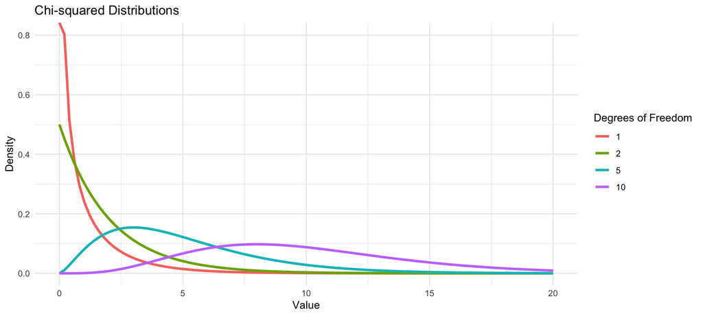

## Why Does Normality of Residuals Matter?

- The MS terms in the F-stats come from SS terms:

\[ SS_{\text{between}} = \sum_{i=1}^k n_i (\bar{Y}_i - \bar{Y})^2 \]

\[ SS_{\text{within}} = \sum_{i=1}^k \sum_{j=1}^{n_i} (Y_{ij} - \bar{Y}_i)^2 \]

## Why Does Normality of Residuals Matter?

- For these to follow \(\chi^2\) distributions:
  - The deviations inside each sum must be **normally distributed**

## How Normal Residuals Lead to \(\chi^2\) Terms

- A residual is just the difference between an individual score and its group mean:

\[ \begin{align*} \varepsilon_{ij} &= \text{observation}_{ij} - \text{group mean}_i \\ \varepsilon_{ij} &= Y_{ij} - \mu_i \end{align*} \]

## How Normal Residuals Lead to \(\chi^2\) Terms

- Assume residuals are independent and normal:

\[ \varepsilon_{ij} = Y_{ij} - \mu_i \sim \mathscr{N}(0, \sigma^2) \]

## How Normal Residuals Lead to \(\chi^2\) Terms

- Then sample means are also normal:

\[ \bar{Y}_i = \mu_i + \frac{1}{n_i} \sum \varepsilon_{ij} \sim \mathscr{N}\left(\mu_i, \frac{\sigma^2}{n_i}\right) \]

## How Normal Residuals Lead to \(\chi^2\) Terms

- So:
- \(\bar{Y}_i - \bar{Y} \sim \text{Normal}\)
- \(Y_{ij} - \bar{Y}_i \sim \text{Normal}\)

## How Normal Residuals Lead to \(\chi^2\) Terms

- Squaring normal variables gives \(\chi^2\) terms:
- \(SS_{\text{between}} \sim \chi^2_{k-1}\)
- \(SS_{\text{within}} \sim \chi^2_{N - k}\)

## Summary: What Normality Ensures

- Normal residuals \(\rightarrow\) normal sample means and deviations
- Squared normal deviations \(\rightarrow\) \(\chi^2\) distributed sums
- \(\chi^2\) numerator & denominator \(\rightarrow\) F-distributed ratio

## Checking Normality of Residuals

- **Residual-based check** (Model-level)
- Fit the ANOVA model and extract residuals:
- Tests whether the model residuals are normally distributed
- This is the standard approach to check the ANOVA assumption
- Use when verifying the validity of the F-test

## Checking Normality in the data

- Recall that normality of residuals is equivalent to normality of the data within each group
- Test normality **within each group**:
- Helps identify which group(s) may be problematic
- Useful when residuals look non-normal and you want to localize the issue

## Checking for normality of residuals

- If you had the residuals from your ANOVA, you could check for normality using a histogram or a statistical test.
- `ezANOVA` hides the residuals by default but we can tell it to provide them using the `return_aov` argument

```r
ezANOVA(
  data = d,
  dv = .(rt),
  wid = .(subject),
  between = .(stimulation, task),
  type = 3,
  return_aov = TRUE # This returns the aov object
)
```

## Example: Extracting residuals from `ezANOVA()`

- Suppose we’re testing how **brain stimulation** (Sham vs. TMS) and **task type** (Working Memory vs. Attention) affect response time in a cognitive task. Our `data.table` looks like this:

```
##    subject stimulation task       rt
## 1        1        Sham   WM 527.5810
## 2        2        Sham   WM 540.7929
## 3        3        Sham   WM 612.3483
## 4        4        Sham   WM 552.8203
## 5        5        Sham   WM 555.1715
## 6        6        Sham   WM 618.6026
## 7        7        Sham   WM 568.4366
## 8        8        Sham   WM 499.3976
## 9        9        Sham   WM 522.5259
## 10      10        Sham   WM 532.1735
## 11      11        Sham   WM 598.9633
## 12      12        Sham   WM 564.3926
## 13      13        Sham   WM 566.0309
## 14      14        Sham   WM 554.4273
```

[output cut: 66 more lines]

## Example: Extracting residuals from `ezANOVA()`

- Run the ANOVA and extract the residuals:

```r
# Run ezANOVA
ez_result <- ezANOVA(
  data = d,
  dv = .(rt),
  wid = .(subject),
  between = .(stimulation, task),
  type = 3,
  return_aov = TRUE
)

# Extract and check residuals
res <- residuals(ez_result$aov)
```

## Example: Extracting residuals from `ezANOVA()`

- Now that we have the residuals, we can check their distribution using the approaches we’ve already covered (e.g., histogram, Shapiro-Wilk test)

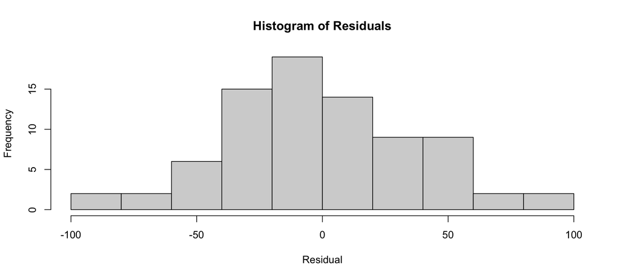

## Example: Extracting residuals from `ezANOVA()`

- Now that we have the residuals, we can check their distribution using the approaches we’ve already covered (e.g., histogram, Shapiro-Wilk test)

```
##
##  Shapiro-Wilk normality test
##
## data:  res
## W = 0.99368, p-value = 0.9663
```

## Homogeneity of variance

- Also called **homoscedasticity**
- Assumes population variances are equal across all groups.
- Especially important when **sample sizes are unequal**.
- **Levene’s test** is a common test for homogeneity of variance and is provided in the `ez` output.

## Robustness of ANOVA Assumptions

- **Normality of residuals**:
  - ANOVA is robust to violations of normality when:
    - Sample sizes are moderate to large (e.g., \(\geq 30\))
    - Group sizes are equal or similar
  - ANOVA is not robust to violations of normality when:
    - Sample sizes are small
    - Group sizes are highly unequal

## Robustness of ANOVA Assumptions

- **Homogeneity of variance**:
  - ANOVA is **more robust** when:
    - Group sizes are equal
    - Variance differences are small to moderate
  - ANOVA is **not robust**, even with equal group sizes, when:
    - Variance differences are **large**

## Violations of homogeneity of variance

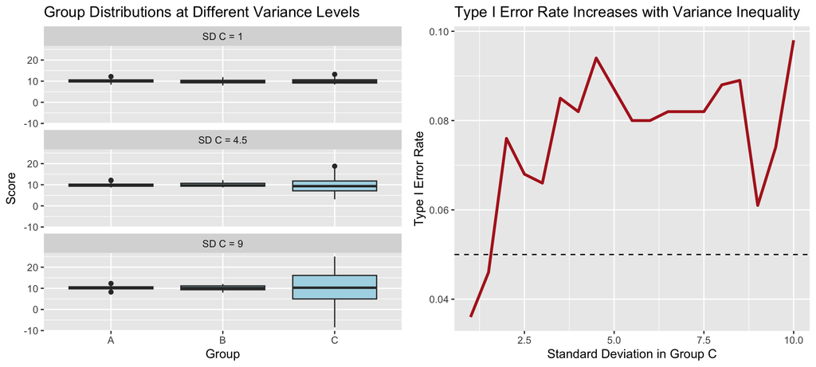

## Question

You run a one-way ANOVA and extract residuals. The histogram below shows the residuals. What should you conclude?

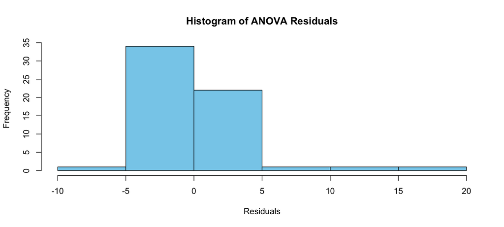

The residuals are clearly skewed, violating the normality assumption of ANOVA. If sample sizes are small or group sizes are unequal, this could invalidate the F-test.

## Question

Consider the boxplot below. All group means are equal. What ANOVA assumption might be violated?

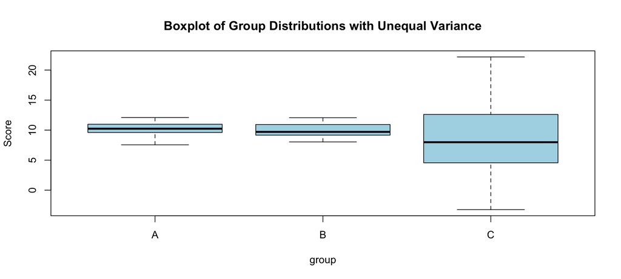

This violates the assumption of **homogeneity of variance**. Although group means are equal, Group C has much higher variability. If group sizes were also unequal, the F-test would be especially unreliable.

## Question

You simulate ANOVA results under the null (equal group means) while increasing the variance in one group. What does this tell you?

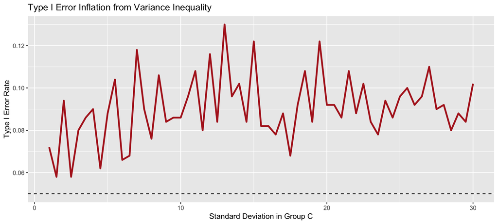

As the variance in Group C increases, the Type I error rate rises above 0.05 — even though group sizes are equal. This demonstrates that ANOVA is not robust to **extreme variance inequality**, especially when variance ratios are large.

## Question

You simulate ANOVA results under the null hypothesis by explicitly generating **non-normal residuals**, especially skewed in the **smallest group**. How does increasing imbalance affect Type I error?

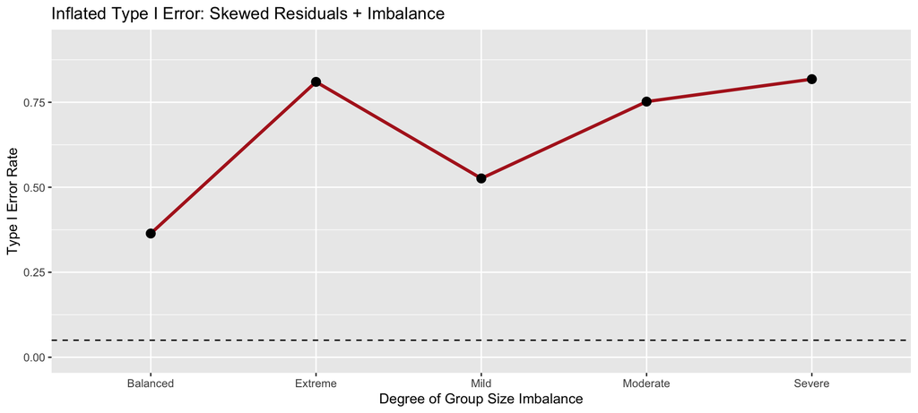

This simulation imposes **non-normal residuals** specifically in the **smallest group**, creating asymmetry in the data that violates ANOVA’s assumptions. As imbalance increases, so does the Type I error rate. This confirms that ANOVA is **not robust** when **residuals are non-normal** and **group sizes are unequal**.